# Marginalizing shocks

# 12 A step back to stay on track

I probably rushed things and skipped a step! I implemented the censoring only after the Cauchy implementation, when it should have been the very first thing to do. Boo me. Below, results with a normally distributed shock model WITH censoring.

```r
data <- readRDS(file = file.path(wd, 'output', 'model', 'data_15nov2025_az592_az628.rds'))
data$rw_obs <- ifelse(data$log_rw_obs == log(1e-4), 0, exp(data$log_rw_obs))

if(FALSE){
  fit <- stan(file=file.path(wd, 'model', 'stan', 'model9_marginalshocks_zerotauinner_censoring.stan'),
            data=data, seed=5838293, chains = 4,
            warmup=1000, iter=2024, refresh=10)
  saveRDS(fit, file.path(wd, 'model/shocks/output/marginal', 'fit_normal_censoring.rds'))
}else{
  fit <- readRDS(file.path(wd, 'model/shocks/output/marginal', 'fit_normal_censoring.rds'))
}
```

Woa! A flood of tree depth warnings.

```r
diagnostics <- util$extract_hmc_diagnostics(fit)
util$check_all_hmc_diagnostics(diagnostics)
```

```
           saturated the maximum treedepth of 10.

           saturated the maximum treedepth of 10.

           saturated the maximum treedepth of 10.

           saturated the maximum treedepth of 10.

  Numerical trajectories that saturate the maximum treedepth have
terminated prematurely.  Increasing max_depth above 10 should result in
more expensive, but more efficient, Hamiltonian transitions.
```

```r
samples <- util$extract_expectand_vals(fit)
base_samples <- util$filter_expectands(samples,
                                       c('alpha',
                                         'beta_gdd', 'beta_sm', 'beta_vpd',
                                         'rho_sh', 'gamma_sh',
                                         'rho_sp', 'gamma_sp',
                                         'sigma',
                                         'phi_sck', 'omega_conc_sck'),
                                       check_arrays = TRUE)
util$check_all_expectand_diagnostics(base_samples)
```

```
rho_sp[1]:


Small empirical effective sample sizes result in imprecise Markov chain
Monte Carlo estimators.
```

Let’s still do some retrodictive checks! On the first stand:

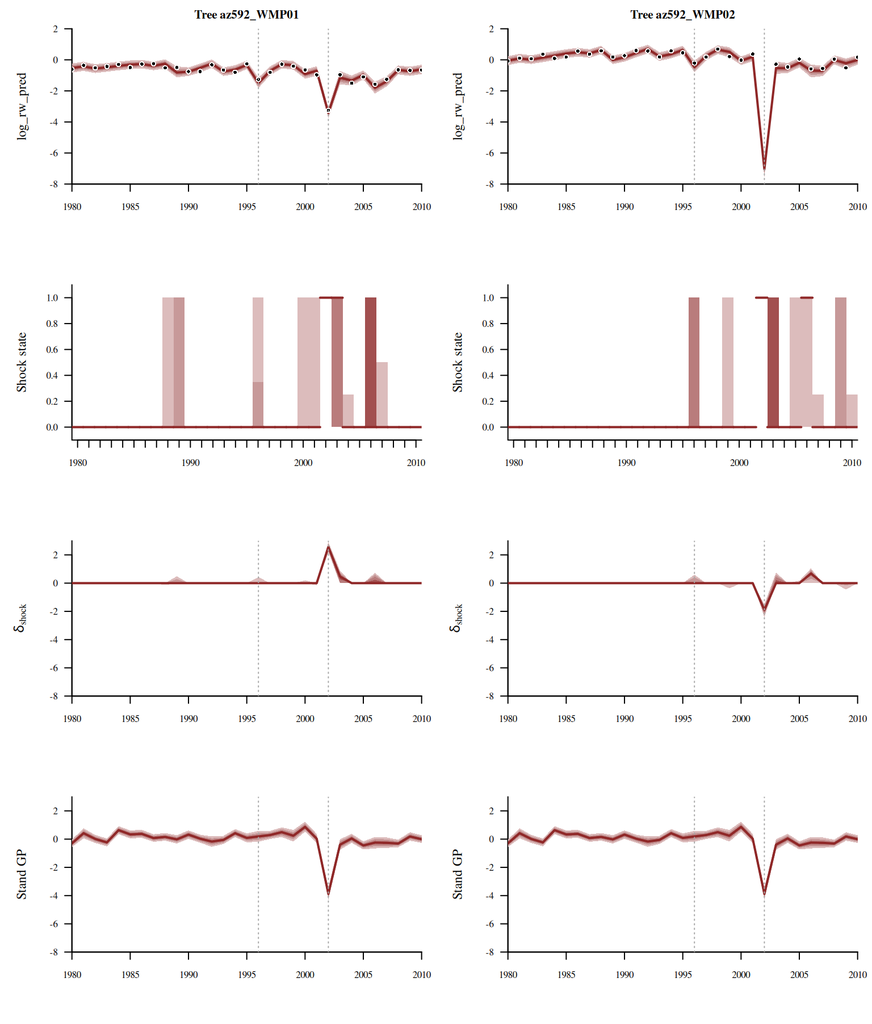

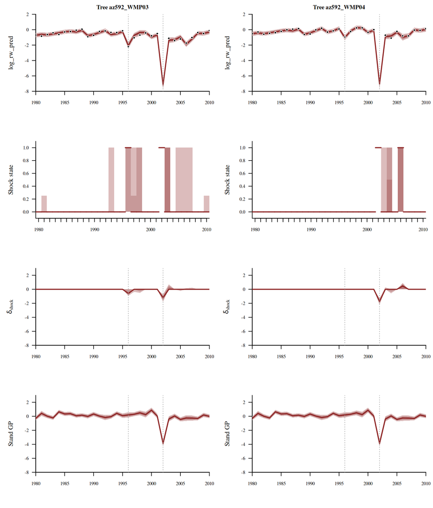

```r
par(mfcol = c(4,2))
for(t in 1:4){
  idxs_t <- data$tree_start_idxs[t]:data$tree_end_idxs[t]
  names <- sapply(idxs_t,
                  function(x) paste0('log_rw_pred[', x, ']'))
  util$plot_conn_pushforward_quantiles(samples, names, data$years[idxs_t],
                                       xlab="", ylab='log_rw_pred', main = paste0('Tree ', data$uniq_tree_ids[t]),
                                       display_ylim=c(-8, 2), display_xlim = c(1980, 2010))
  points(data$years[idxs_t], ifelse(data$log_rw_obs[idxs_t] == log(1e-4), NA, data$log_rw_obs[idxs_t]), pch=16, cex=1, col="white")
  points(data$years[idxs_t], ifelse(data$log_rw_obs[idxs_t] == log(1e-4), NA, data$log_rw_obs[idxs_t]), pch=16, cex=0.6, col="black")
  abline(v =  c(2002,1996), lty = 3, col="darkgrey")

  names <- sapply(idxs_t,
                  function(x) paste0('sck_state[', x, ']'))
  ticks <- c(unlist(lapply(seq(1980, 2000,10), function(x) c(x, rep(NA, 9)))), '2010')
  util$plot_disc_pushforward_quantiles(samples, names, data$years[idxs_t],
                                       xlab="", ylab='Shock state',
                                       display_ylim=c(-0.1, 1.1),
                                       xticklabs =  ticks)
  abline(v =  c(2002,1996), lty = 3, col="darkgrey")

  names <- sapply(idxs_t,
                  function(x) paste0('delta_sck[', x, ']'))
  util$plot_conn_pushforward_quantiles(samples, names, data$years[idxs_t],
                                       xlab="", ylab=expression(delta[shock]),
                                       display_ylim=c(-8, 3), display_xlim = c(1980, 2010))
  abline(v =  c(2002,1996), lty = 3, col="darkgrey")

  names <- sapply(1:data$N_all_years,
                  function(x) paste0('f_sh[', data$stand_idxs[t],',',x, ']'))
  util$plot_conn_pushforward_quantiles(samples, names, data$all_years,
                                       xlab="", ylab='Stand GP',
                                       display_ylim=c(-8, 3), display_xlim = c(1980, 2010))
  abline(v = c(2002,1996), lty = 3, col="darkgrey")
}
```

The model seems to over-regularize the large negative shocks. We obtain a $\tau_\text{outer}^\text{shock}$ rather small compared to what our broad prior would suggest:

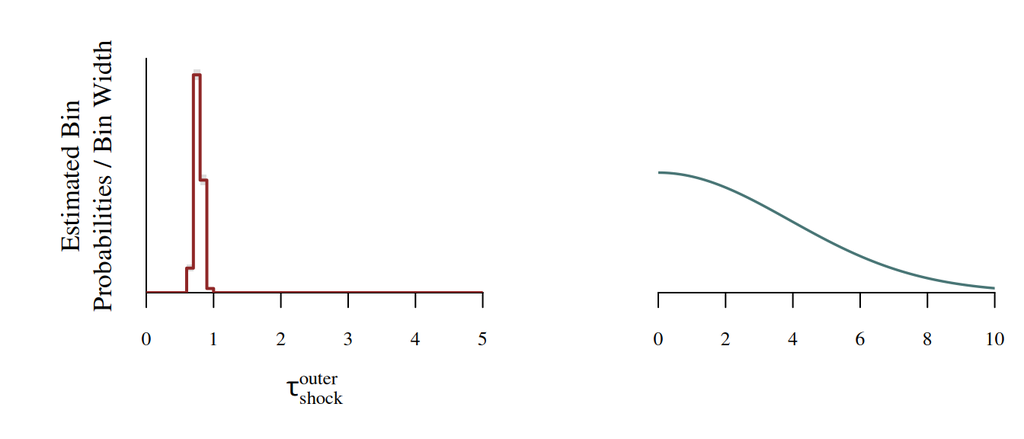

```r
par(mfcol = c(1,2))
util$plot_expectand_pushforward(samples[['outer_tau_sck']], 50,
                                flim = c(0,5),
                                display_name=expression(tau[shock]^outer))
plot(1, type = "n", xlab = "", ylab = "", xlim = c(0, 10), ylim = c(0, 0.2),
     xaxs = "i", yaxs = "i", bty = "n", yaxt = "n")
xs <- seq(0, 10, 0.01)
ys <- dnorm(xs, 0, 10 / 2.57)
lines(xs, ys, lwd=2.7, col='white')
lines(xs, ys, lwd=1.7, col=util$c_mid_teal)
```

This would lead me to consider a distribution a bit less rigid.